# **PENANGANAN AUTOKORELASI PADA DATA IPM KABUPATEN SUKABUMI**

Joshua Bryan Wijaya~G1401231082

2025-09-04

# **LIBRARY**

```r
library(dplyr)
library(lmtest)
```

```r
library(readxl)
library(ggplot2)
library(devtools)
library(orcutt)
```

# **DATA**

```r
data <- read_xlsx("C:/Users/Dell/OneDrive/Desktop/SEMESTER 5/MPDW/Pertemuan 2/sukabumi.xlsx")
data
```

```
## # A tibble: 15 × 2
##    Tahun   IPM
##    <dbl> <dbl>
##  1  2010  60.7
##  2  2011  61.1
##  3  2012  62.3
##  4  2013  63.6
##  5  2014  64.1
##  6  2015  64.4
##  7  2016  65.1
##  8  2017  65.5
##  9  2018  66.0
## 10  2019  66.9
## 11  2020  66.9
## 12  2021  67.1
## 13  2022  67.6
## 14  2023  68.5
## 15  2024  69.0
```

# **EKSPLORASI**

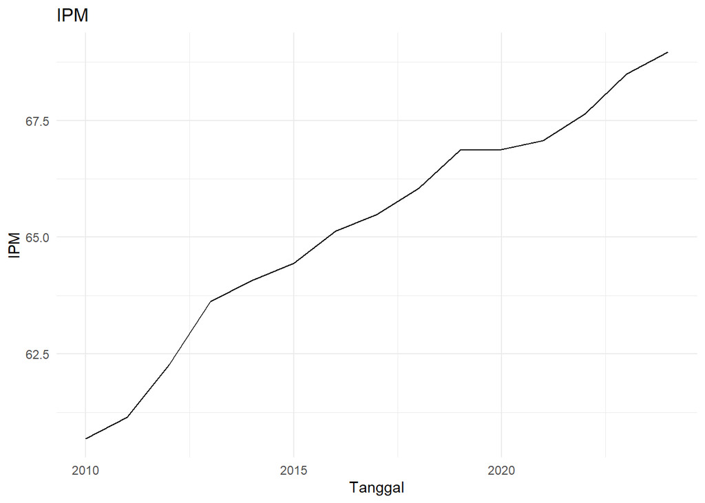

```r
ggplot(data, aes(x = Tahun, y = IPM)) +
  geom_line() +
  labs(title = "IPM", x = "Tanggal", y = "IPM") +
  theme_minimal()
```

# **PEMODELAN REGRESI**

```r
y <- data$IPM
x <- data$Tahun
model <- lm(y~x)
summary(model)
```

```
##
## Call:
## lm(formula = y ~ x)
##
## Residuals:
##      Min       1Q   Median       3Q      Max
## -0.75362 -0.31205 -0.05619  0.37010  0.61581
##
## Coefficients:
##               Estimate Std. Error t value Pr(>|t|)
## (Intercept) -1.065e+03  5.488e+01  -19.40 5.57e-11 ***
## x            5.603e-01  2.721e-02   20.59 2.63e-11 ***
## ---
## Signif. codes:  0 '***' 0.001 '**' 0.01 '*' 0.05 '.' 0.1 ' ' 1
##
## Residual standard error: 0.4553 on 13 degrees of freedom
## Multiple R-squared:  0.9703, Adjusted R-squared:  0.968
## F-statistic:   424 on 1 and 13 DF,  p-value: 2.628e-11
```

# **UJI ASUMSI**

## Uji Asumsi Normalitas

$H_0$ : Residual berdistribusi normal  
$H_1$ : Residual tidak berdistribusi normal

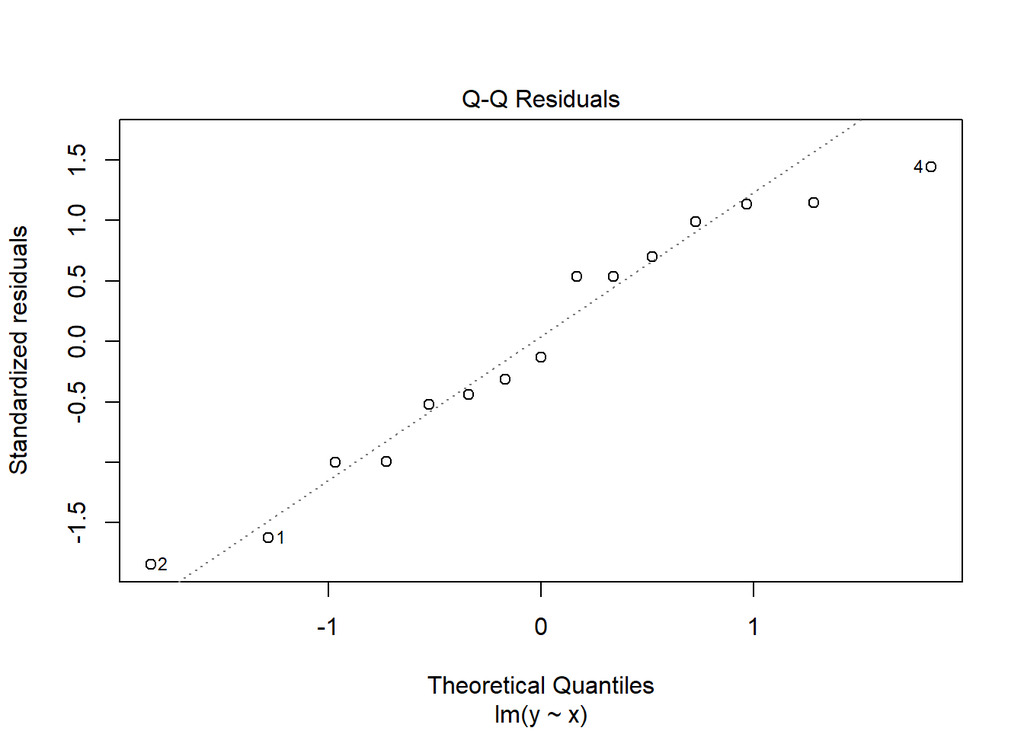

```r
plot(model,2)
```

```r
shapiro.test(model$residuals)
```

```
##
##  Shapiro-Wilk normality test
##
## data:  model$residuals
## W = 0.94211, p-value = 0.4096
```

Melalui Quantile-quantile plot, terlihat bahwa residu model bergerak di sekitar garis normalitas (residu menyebar normal), selain itu, melalui uji formal (Shapiro Wilk Test), diperoleh $p-value > 0.05$. Dengan demikian, pada taraf nyata ($\alpha$) = 5%, tidak cukup bukti untuk menolak $H_0$ sehingga residual berdistribusi normal .

## Uji Asumsi Homogenitas

$H_0$ : Ragam sisaan konstan (homoskedastisitas)  
$H_1$ : Ragam sisaan tidak konstan (Heteroskedastisitas)

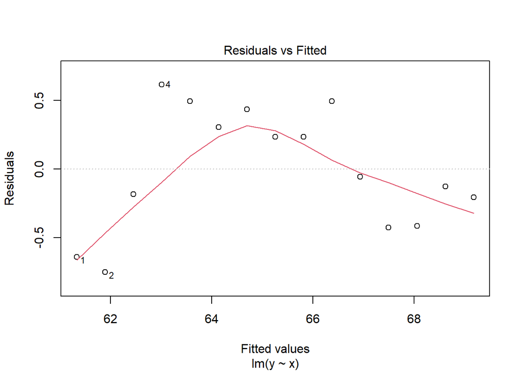

```r
plot(model,1)
```

```r
bptest(model)
```

```
##
##  studentized Breusch-Pagan test
##
## data:  model
## BP = 5.8978, df = 1, p-value = 0.01516
```

Melalui Residual vs Fitted Plot, terlihat bahwa lebar residu model tidak sama, hal ini mengindikasikan heteroskedastisitas (ragam sisaan tidak konstan). Selain itu, melalui uji formal (Breusch-Pagan Test), diperoleh $p-value < 0.05$. Dengan demikian, pada taraf nyata ($\alpha$) = 5%, cukup bukti untuk menolak $H_0$ sehingga ragam sisaan tidak konstan (heteroskedastisitas) .

## Uji Asumsi Autokorelasi

$H_0$ : Sisaan saling bebas (Tidak ada autokorelasi)  
$H_1$ : Sisaan tidak saing bebas (Autokorelasi)  
### Plot ACF

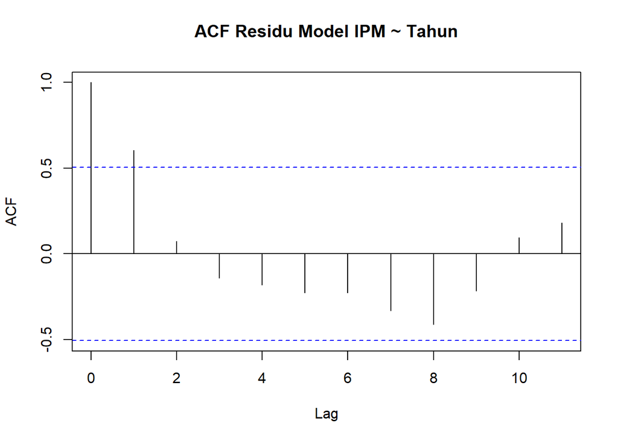

```r
resid_model <- residuals(model)
acf(resid_model, main = "ACF Residu Model IPM ~ Tahun")
```

Dilakukan uji non-formal melalui plot ACF (Autocorrelation Function). Nilai garis pada setiap lag data merupakan nilai korelasi residu pada lag ke-k dengan residu pada lag ke- (k-1). Oleh karena itu, pada plot ACF, lag 0 selalu bernilai 1 (karena berkorelasi dengan dirinya sendiri) dan sudah pasti melewati ambang batas signifikansi.

Untuk garis biru sendiri merupakan batas signifansi
$$\pm \frac{2}{\sqrt{n}}$$
Yang dalam case ini, berarti nilainya ~ 0.53, sehingga baik itu korelasi positif maupun negatif, yang melewati ambang ini diasumsikan residu tidak saling bebas, dan disana terlihat bahwa lag 1 melewati batas tersebut.

### Plot Residual vs Order

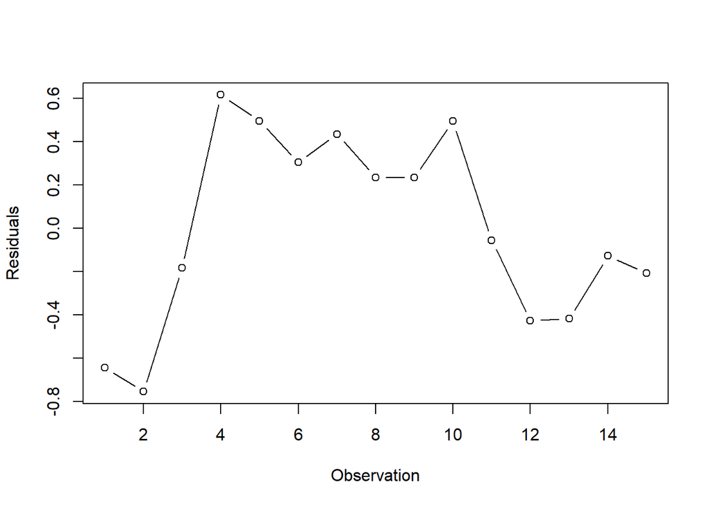

```r
plot(x = 1:dim(data)[1],
     y = model$residuals,
     type = 'b',
     ylab = "Residuals",
     xlab = "Observation")
```

Melalui Residual vs Order, terlihat bahwa residu model memliki pola naik turun dalam periode tertentu. Hal ini mengindikasikan residu tidak saling bebas .

### Uji Formal Durbin Wattson Test

```r
dwtest(model)
```

```
##
##  Durbin-Watson test
##
## data:  model
## DW = 0.62408, p-value = 0.0001377
## alternative hypothesis: true autocorrelation is greater than 0
```

Berdasarkan hasil DW Test, didapatkan nilai $DW = 0.62408$ dan *p-value* = $0.0001377$. Berdasarkan tabel Durbin-Watson diperoleh nilai $DL = 1.0450$ dan $DU = 1.3503$. Nilai DW kurang dari nilai DL. Artinya, terdapat autokorelasi positif pada residu model. Ditambah, dengan nilai *p-value* < 0.05 dapat disimpulkan bahwa tolak H0, cukup bukti mengatakan adanya autokorelasi. Oleh karena itu, diperlukan penangan autokorelasi. Penanganan yang akan digunakan menggunakan dua metode, yaitu Cochrane-Orcutt dan Hildret-Lu.

# **PENANGANAN MASALAH AUTOKORELASI**

Untuk mengatasi masalah autokorelasi, dibutuhkan $\rho$ optimal sebagai komponen utama untuk regresi residual dengan lagnya sendiri. Mencari nilai $\rho$ optimal dapat menggunakan dua cara, yakni menggunakan metode Orhane-Cutt dan Hildreth-Lu

## **PENANGANAN ORHANE CUTT**

```r
oc <- cochrane.orcutt(model)
summary(oc)
```

```
## Call:
## lm(formula = y ~ x)
##
##                Estimate  Std. Error t value  Pr(>|t|)
## (Intercept) -927.527214  108.992346  -8.510 1.986e-06 ***
## x              0.492329    0.053979   9.121 9.589e-07 ***
## ---
## Signif. codes:  0 '***' 0.001 '**' 0.01 '*' 0.05 '.' 0.1 ' ' 1
##
## Residual standard error: 0.3053 on 12 degrees of freedom
## Multiple R-squared:  0.8739 ,  Adjusted R-squared:  0.8634
## F-statistic: 83.2 on 1 and 12 DF,  p-value: < 9.589e-07
##
## Durbin-Watson statistic
## (original):    0.62408 , p-value: 1.377e-04
## (transformed): 1.75428 , p-value: 2.09e-01
```

model yang dihasilkan dengan metode Orhane-Cutt adalah
$$y_i=-927.53+0.49x_t$$

## **PENANGANAN HILDRETH-LU**

### Funtion

```r
hildreth.lu <- function(rho, model){
  x <- model.matrix(model) [,-1]
  y <- model.response(model.frame(model))
  n <- length(y)
  t <- 2:n
  y <- y[t] - rho*y[t-1]
  x <- x[t] - rho*x[t-1]

  return(lm(y~x))
}
```

### Identifikasi Batas Bawah dan Batas Atas

```r
rho <- seq(0.01, 0.99,by = 0.01)
```

Ini merupakan batas pertama yang ditentukan, baik untuk batas bawah dan batas atas. Range awal langsung saya berikan angka yang cukup spesifik dengan dua digit dibelakang nol, agar tidak usah mengulang-ulang penentuan batas untuk mencari nilai $\rho$ optimal. Dengan sequence seperti ini, $\rho$ dengan SSE terkecil dapat langsung diambil sebagai model

### Pencarian Rho optimal

```r
y <- data$IPM
x <- data$Tahun
fit <- lm(y~x)
tab <- data.frame('rho' = rho,
                  'SSE' = sapply(rho, function(r) {deviance(hildreth.lu(r,fit))}))
round(tab,4)
```

```
##     rho    SSE
## 1  0.01 2.1163
## 2  0.02 2.0841
## 3  0.03 2.0524
## 4  0.04 2.0213
## 5  0.05 1.9907
## 6  0.06 1.9606
## 7  0.07 1.9311
## 8  0.08 1.9020
## 9  0.09 1.8735
## 10 0.10 1.8456
## 11 0.11 1.8181
## 12 0.12 1.7912
## 13 0.13 1.7648
## 14 0.14 1.7390
```

[output cut: 85 more lines]

```r
tab
```

```
##     rho      SSE
## 1  0.01 2.116263
## 2  0.02 2.084077
## 3  0.03 2.052418
## 4  0.04 2.021287
## 5  0.05 1.990683
## 6  0.06 1.960607
## 7  0.07 1.931059
## 8  0.08 1.902038
## 9  0.09 1.873545
## 10 0.10 1.845579
## 11 0.11 1.818141
## 12 0.12 1.791231
## 13 0.13 1.764848
## 14 0.14 1.738993
```

[output cut: 85 more lines]

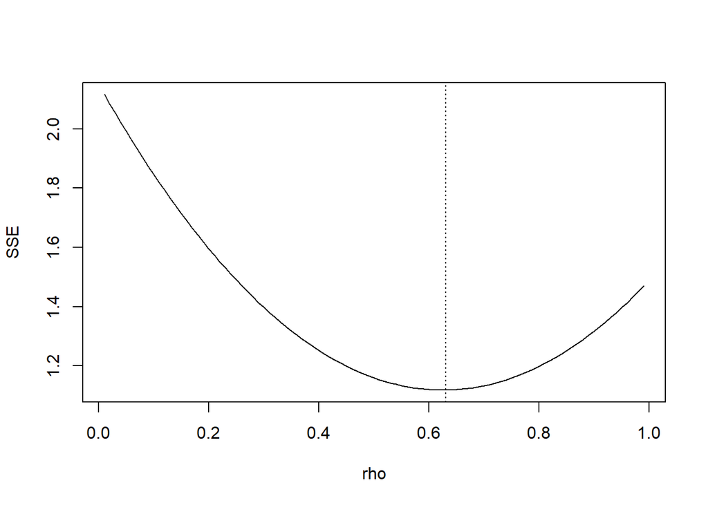

```r
plot(SSE~rho, tab,type = 'l')
abline(v = tab[tab$SSE == min(tab$SSE),'rho'], lty=3)
```

Melalui kombinasi nilai SSE yang dihasilkan dan hasil dari plot SSE versus $\rho$, ditemukan bahwa $\rho$ optimal ada pada rentang angka 0.6 hingga 0.65, tepatnya kalo dilihat dari SSE terendahnya ada pada rho = 0.63 yang bernilai 1.118417.

### Pemodelan Regresi dengan Rho Optimal

```r
fit <- hildreth.lu(0.63,fit)
summary(fit)
```

```
##
## Call:
## lm(formula = y ~ x)
##
## Residuals:
##      Min       1Q   Median       3Q      Max
## -0.55079 -0.10270 -0.00821  0.15430  0.58023
##
## Coefficients:
##              Estimate Std. Error t value Pr(>|t|)
## (Intercept) -342.4347    40.8697  -8.379 2.33e-06 ***
## x              0.4913     0.0547   8.982 1.13e-06 ***
## ---
## Signif. codes:  0 '***' 0.001 '**' 0.01 '*' 0.05 '.' 0.1 ' ' 1
##
## Residual standard error: 0.3053 on 12 degrees of freedom
## Multiple R-squared:  0.8705, Adjusted R-squared:  0.8597
## F-statistic: 80.67 on 1 and 12 DF,  p-value: 1.128e-06
```

Model yang dihasilkan adalah
$$y_i=-342.43+0.49x_t$$
Berdasarkan ringkasan model dapat diketahui bahwa hasil uji F memiliki *p-value* < $\alpha$ (5%). Artinya, minimal terdapat satu variabel yang berpengaruh nyata terhadap model (walau sebenarnya, karena ini regresi sederhana dengan 1 variabel, hasil ini juga merepresentasikan bahwa pengaruh peubah x (intersep) itu signifikan). Hasil uji-t parsial kedua parameter regresi, yaitu intersep dan koefisien regresi juga menunjukkan hal yang sama, yaitu memiliki *p-value* < $\alpha$ (5%) sehingga nyata dalam taraf 5%. TAPII, model perlu di transformasi balik lagi nantinya untuk keperluan interpretasi. Namun, untuk pengecekan uji asumsi autokorelasi apakah sudah terpenuhi atau belum, uji asumsinya akan dilakukan pada model yang ini (jadi, model yang lolos uji asumsi autokorelasi itu adalah model yang hasil transformasi)

## Uji asumsi model setelah penanganan

```r
dwtest(fit)
```

```
##
##  Durbin-Watson test
##
## data:  fit
## DW = 1.7607, p-value = 0.2127
## alternative hypothesis: true autocorrelation is greater than 0
```

## Transformasi balik

```r
cat("Y = ", coef(fit)[1]/(1-0.63), " + ", coef(fit)[2], "X", sep="")
```

```
## Y = -925.4991 + 0.4913264X
```

Setelah ditransformasi balik, model yang dihasilkan adalah
$$y_i=-925.50+0.49x_t$$
.

# **PERBANDINGAN MODEL KETIGA METODE**

[output not shown]

Ternyata, model setelah di transformasi menggunakan metode Orhane-Cutt dan Hildreth-Lu mengalami penurunan pada nilai RSE dan$R^2$ nya. Kemudian, lebih lanjut, perbedaan metode Orhane-Cutt dan Hildreth-Lu adalah metode pencarian nilai $\rho$ optimumnya, Orhane-Cutt menggunakan iterasi sedangkan Hildreth-Lu menggunakan batas bawah dan atas. Komputasi menggunakan R menghasilkan nilai $\rho$ optimum yang lebih presisi.